# Brad PT

Jason

# ABSTRACT

## Purpose

**PURPOSE/HYPOTHESIS**  
Chronic pain (CP) is a widespread and costly condition, affecting nearly 100 million Americans and costing over $600 billion annually. Evidence suggests that compared to healthy controls (HC), chronic pain populations experience problems with sleep and depression. Less understood is how whether these problems are differentially experienced by different chronic pain conditions (i.e., chronic low back pain and fibrimyalgia). To address this questions, questionnaire data regarding sleep, depression and pain were collected.

## Subjects

For all groups, potential participants were excluded if (1) they could not refrain from usage of analgesics the day before and of their scan, (2) tested positive on a pre-MRI metal screening, (3) were pregnant, (4) and/or did not display pain symptoms consistent with Quebec Task Force and Spinal Disorders diagnostic criteria.

All participants for this study provided written consent. Data was collected from 158 participants (HC = 50, 27 females); CLBP = 64, 41 females; FM = 44, 39 females). This study was approved by the Institutional Review Board at the University of Missouri.

## Methods

**MATERIALS AND METHODS**  
As part of the study, participants completed a variety of questionnaires, via secure RedCap research database, related to pain variables

Participants completed the Beck Depression Inventory-II (BDI-II), Epworth Sleepiness Scale, McGill-Melzack Pain Questionnaire and Pittsburg Sleep Quality Index (PSQI). A subgroup of participantas also completed the Insomnia Severity Index.

## Clinical Relevance

**CLINICAL RELEVANCE**  
This study supported by NINR grant #R01NR015314

# GOALS

Questions asked for this study

**Q1**: What is the correlation between sleep and pain measures?  
* Correlation

**Q2**: Controlling for pain, is there a difference in sleep variables?  
* ANCOVA  
* Regression

# MEASURES

Pittsburg Sleep Questionnaire  
Epsworth Sleepiness Scale  
Insomnia Severity Index  
McGill Pain Questionnaire  
Beck Depression Inventory

# DATA

Import data from GitHub

## Score PSQI

> The global PSQI score is then calculated by totaling the seven component scores, providing an overall score ranging from 0 to 21, where lower scores denote a healthier sleep quality.

The PSQI data has been updated, processed, clean and scored

## DATA FOR ANALYSES

Create a small dataset (dat.sm) that includes only the variables of interest.

Also create a dataset of subjects with ISI data (dat.isi).

## DATA VARIANCE

```
[1] "slpDist"
```

```
[1] "slpDist"
```

```
character(0)
```

## DESCRIPTIVES

Group by sex for overall sample.

| Group | Sex Female | Sex Male | Total |
| --- | --- | --- | --- |
| HC | 27 | 23 | 50 |
| CLBP | 41 | 23 | 64 |
| FM | 39 | 5 | 44 |
| Total | 107 | 51 | 158 |

## PLOTS

### BAR PLOTS

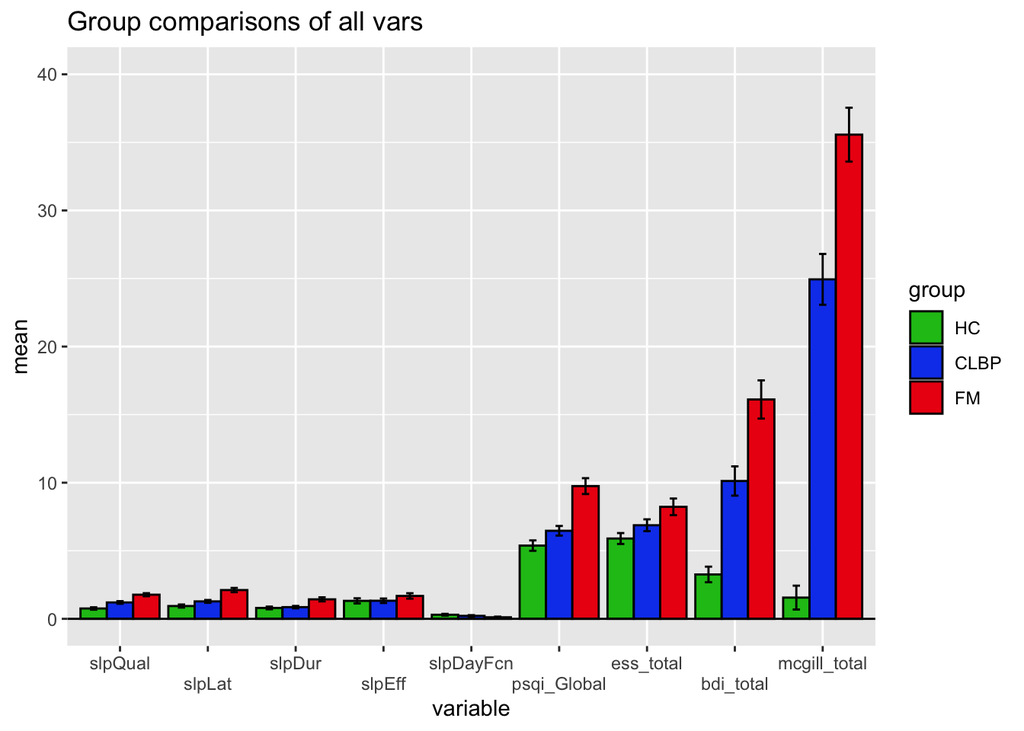

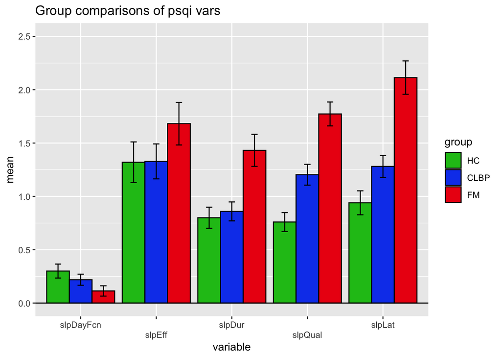

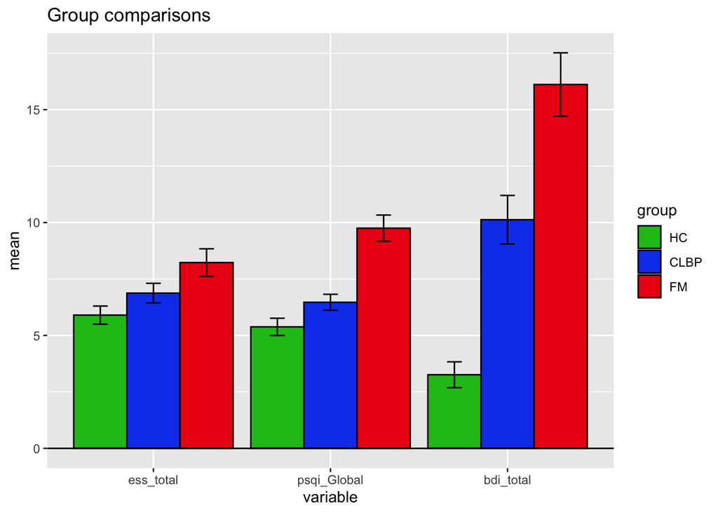

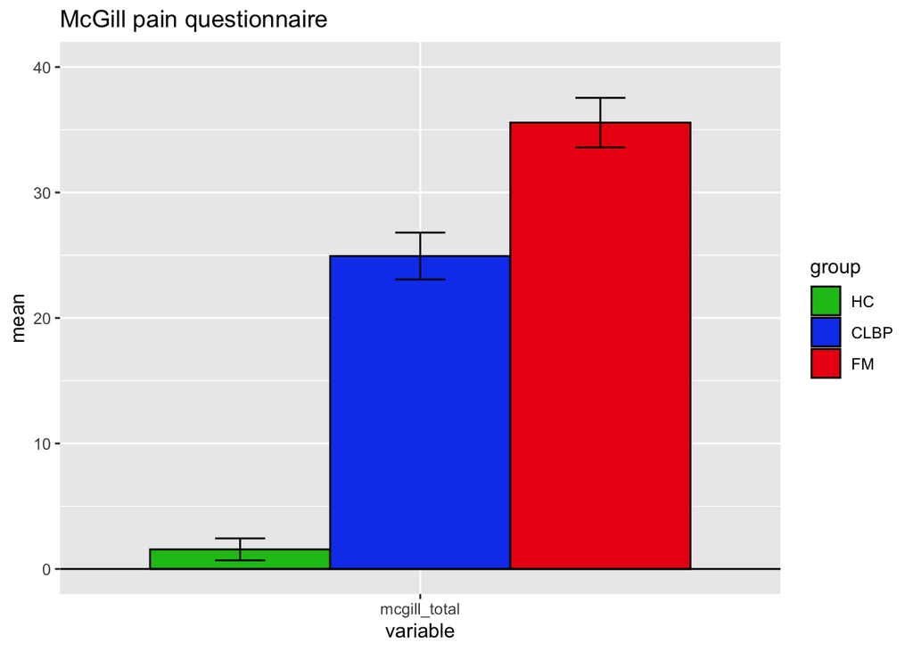

### CORR PLOTS

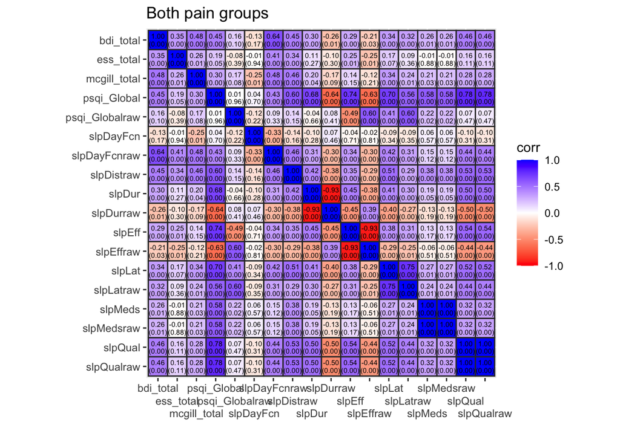

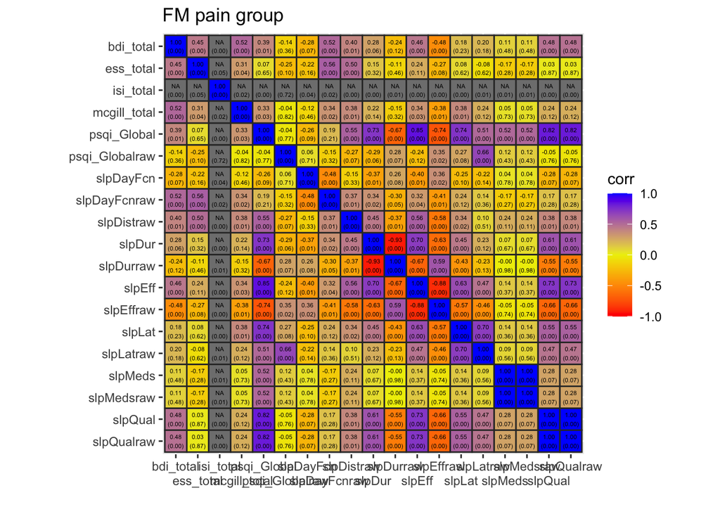

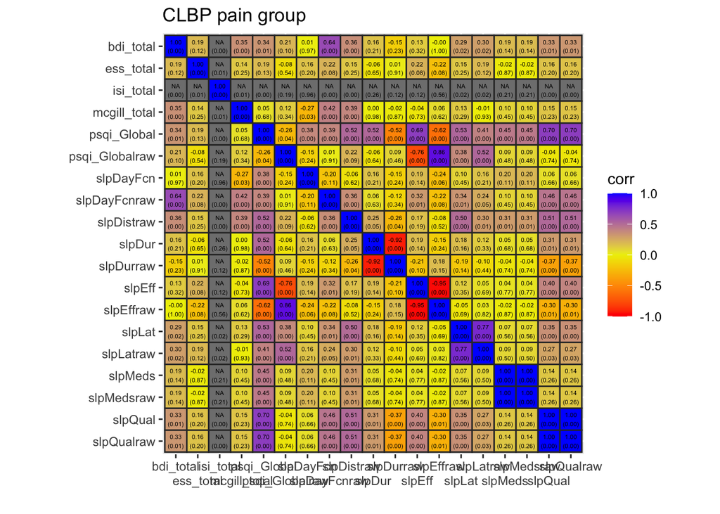

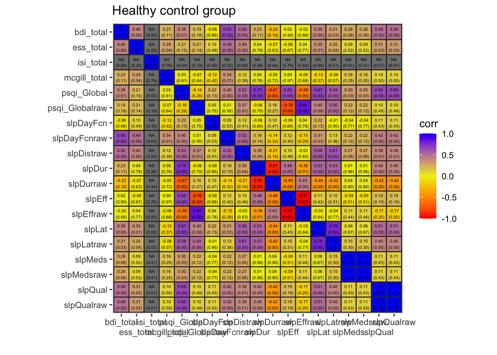

The end of corr plots

## ANOVA (Main effect of group)

ANOVA full model

| Name | p.value |
| --- | --- |
| slpQual | 1.87e-09 |
| slpLat | 4.37e-09 |
| slpDur | 0.000197 |
| slpEff | 0.318 |
| slpDist | 0.0365 |
| slpMeds | 9.37e-09 |
| slpDayFcn | 0.0906 |
| psqi_Global | 4.43e-10 |
| ess_total | 0.00597 |
| isi_total | 7.57e-10 |
| bdi_total | 1.29e-12 |
| mcgill_total | 4.96e-28 |
| TIB | 0.865 |

Note:  
Red = Significant main effect for group (p ≤ 0.05)

ANOVA #2 full model

| Name | p.value |
| --- | --- |
| slpQualraw | 1.87e-09 |
| slpLatraw | 5.36e-08 |
| slpDurraw | 0.0013 |
| slpEffraw | 0.695 |
| slpDistraw | 6.09e-18 |
| slpMedsraw | 9.37e-09 |
| slpDayFcnraw | 9.76e-12 |
| psqi_Globalraw | 1.71e-05 |
| ess_total | 0.00597 |
| isi_total | 7.57e-10 |
| bdi_total | 1.29e-12 |
| mcgill_total | 4.96e-28 |
| TIB | 0.865 |

Note:  
Red = Significant main effect for group (p ≤ 0.05)

ISI subgroup ANOVA full model

| Name | p.value |
| --- | --- |
| slpQual | 4.01e-05 |
| slpLat | 0.00123 |
| slpDur | 0.00795 |
| slpEff | 0.353 |
| slpDist | 0.022 |
| slpMeds | 0.000275 |
| slpDayFcn | 0.0846 |
| psqi_Global | 6.43e-05 |
| ess_total | 0.0723 |
| isi_total | 7.57e-10 |
| bdi_total | 3.49e-06 |
| mcgill_total | 1.24e-14 |
| TIB | 0.383 |

Note:  
Red = Significant main effect for group (p ≤ 0.05)

## POSTHOC

PostHoc group comparisons: **See** *Note* at table end

| comparison | diff | conf.low | conf.high | adj.p.value |
| --- | --- | --- | --- | --- |
| **Sleep Quality** |  |  |  |  |
| CLBP-HC | 0.443 | 0.120 | 0.766 | 0.00411 |
| FM-HC | 1.013 | 0.659 | 1.367 | 7.56e-10 |
| FM-CLBP | 0.570 | 0.234 | 0.905 | 0.000268 |
| **Sleep Latency** |  |  |  |  |
| CLBP-HC | 0.341 | -0.052 | 0.735 | 0.103 |
| FM-HC | 1.174 | 0.743 | 1.604 | 4.1e-09 |
| FM-CLBP | 0.832 | 0.424 | 1.240 | 9.81e-06 |
| **Sleep Duration** |  |  |  |  |
| CLBP-HC | 0.059 | -0.297 | 0.415 | 0.918 |
| FM-HC | 0.632 | 0.242 | 1.022 | 0.000535 |
| FM-CLBP | 0.572 | 0.203 | 0.942 | 0.00098 |
| **Sleep Efficacy** |  |  |  |  |
| CLBP-HC | 0.008 | -0.584 | 0.600 | 0.999 |
| FM-HC | 0.362 | -0.287 | 1.010 | 0.386 |
| FM-CLBP | 0.354 | -0.261 | 0.968 | 0.363 |
| **Sleep Disturbance** |  |  |  |  |
| CLBP-HC | 0.060 | -0.000 | 0.120 | 0.0512 |
| FM-HC | 0.060 | -0.006 | 0.126 | 0.0829 |
| FM-CLBP | 0.000 | -0.063 | 0.063 | 1 |
| **Sleep Medications** |  |  |  |  |
| CLBP-HC | 0.258 | -0.208 | 0.724 | 0.391 |
| FM-HC | 1.316 | 0.806 | 1.827 | 2.38e-08 |
| FM-CLBP | 1.058 | 0.575 | 1.542 | 2.03e-06 |
| **Sleep Daytime Functioning** |  |  |  |  |
| CLBP-HC | -0.081 | -0.264 | 0.101 | 0.544 |
| FM-HC | -0.186 | -0.386 | 0.013 | 0.0732 |
| FM-CLBP | -0.105 | -0.294 | 0.084 | 0.39 |
| **PSQI Global** |  |  |  |  |
| CLBP-HC | 1.089 | -0.303 | 2.480 | 0.156 |
| FM-HC | 4.370 | 2.846 | 5.894 | 6.86e-10 |
| FM-CLBP | 3.281 | 1.838 | 4.725 | 8.11e-07 |
| **ESS Total** |  |  |  |  |
| CLBP-HC | 0.975 | -0.574 | 2.524 | 0.299 |
| FM-HC | 2.327 | 0.631 | 4.023 | 0.00406 |
| FM-CLBP | 1.352 | -0.255 | 2.959 | 0.118 |
| **ISI Total** |  |  |  |  |
| CLBP-HC | 4.171 | 0.547 | 7.794 | 0.0199 |
| FM-HC | 10.250 | 6.728 | 13.772 | 2.19e-09 |
| FM-CLBP | 6.079 | 3.080 | 9.079 | 1.64e-05 |
| **BDI Total** |  |  |  |  |
| CLBP-HC | 6.865 | 3.426 | 10.304 | 1.53e-05 |
| FM-HC | 12.854 | 9.087 | 16.620 | 5.43e-13 |
| FM-CLBP | 5.989 | 2.420 | 9.557 | 0.00032 |
| **McGill Total** |  |  |  |  |
| CLBP-HC | 23.378 | 17.897 | 28.858 | 1.42e-14 |
| FM-HC | 34.008 | 28.006 | 40.010 | 0 |
| FM-CLBP | 10.631 | 4.944 | 16.317 | 5.38e-05 |
| **Time in Bed** |  |  |  |  |
| CLBP-HC | -0.439 | -5.355 | 4.476 | 0.976 |
| FM-HC | -1.215 | -6.598 | 4.168 | 0.855 |
| FM-CLBP | -0.776 | -5.876 | 4.324 | 0.931 |

Note:  
Red = Significant group tests (p ≤ 0.05)

PostHoc (PSQI raw) group comparisons: **See** *Note* at table end

| comparison | diff | conf.low | conf.high | adj.p.value |
| --- | --- | --- | --- | --- |
| **Sleep Quality raw** |  |  |  |  |
| CLBP-HC | 0.443 | 0.120 | 0.766 | 0.00411 |
| FM-HC | 1.013 | 0.659 | 1.367 | 7.56e-10 |
| FM-CLBP | 0.570 | 0.234 | 0.905 | 0.000268 |
| **Sleep Latency raw** |  |  |  |  |
| CLBP-HC | 6.502 | -4.155 | 17.159 | 0.321 |
| FM-HC | 28.805 | 17.135 | 40.476 | 8.85e-08 |
| FM-CLBP | 22.303 | 11.246 | 33.361 | 1.24e-05 |
| **Sleep Duration raw** |  |  |  |  |
| CLBP-HC | -0.163 | -0.699 | 0.374 | 0.753 |
| FM-HC | -0.871 | -1.459 | -0.283 | 0.00171 |
| FM-CLBP | -0.708 | -1.265 | -0.151 | 0.00853 |
| **Sleep Efficacy raw** |  |  |  |  |
| CLBP-HC | -0.287 | -14.557 | 13.983 | 0.999 |
| FM-HC | -4.998 | -20.626 | 10.631 | 0.73 |
| FM-CLBP | -4.711 | -19.517 | 10.096 | 0.732 |
| **Sleep Disturbance raw** |  |  |  |  |
| CLBP-HC | 5.026 | 3.150 | 6.903 | 7.24e-09 |
| FM-HC | 8.756 | 6.701 | 10.812 | 1.45e-14 |
| FM-CLBP | 3.730 | 1.783 | 5.677 | 3.43e-05 |
| **Sleep Medications raw** |  |  |  |  |
| CLBP-HC | 0.258 | -0.208 | 0.724 | 0.391 |
| FM-HC | 1.316 | 0.806 | 1.827 | 2.38e-08 |
| FM-CLBP | 1.058 | 0.575 | 1.542 | 2.03e-06 |
| **Sleep Daytime Functioning raw** |  |  |  |  |
| CLBP-HC | 0.703 | 0.096 | 1.309 | 0.0187 |
| FM-HC | 2.140 | 1.476 | 2.804 | 6.9e-12 |
| FM-CLBP | 1.438 | 0.808 | 2.067 | 7.15e-07 |
| **PSQI Global raw** |  |  |  |  |
| CLBP-HC | 12.482 | -3.805 | 28.770 | 0.168 |
| FM-HC | 36.162 | 18.325 | 54.000 | 1.11e-05 |
| FM-CLBP | 23.680 | 6.781 | 40.579 | 0.00325 |
| **ESS Total** |  |  |  |  |
| CLBP-HC | 0.975 | -0.574 | 2.524 | 0.299 |
| FM-HC | 2.327 | 0.631 | 4.023 | 0.00406 |
| FM-CLBP | 1.352 | -0.255 | 2.959 | 0.118 |
| **ISI Total** |  |  |  |  |
| CLBP-HC | 4.171 | 0.547 | 7.794 | 0.0199 |
| FM-HC | 10.250 | 6.728 | 13.772 | 2.19e-09 |
| FM-CLBP | 6.079 | 3.080 | 9.079 | 1.64e-05 |
| **BDI Total** |  |  |  |  |
| CLBP-HC | 6.865 | 3.426 | 10.304 | 1.53e-05 |
| FM-HC | 12.854 | 9.087 | 16.620 | 5.43e-13 |
| FM-CLBP | 5.989 | 2.420 | 9.557 | 0.00032 |
| **McGill Total** |  |  |  |  |
| CLBP-HC | 23.378 | 17.897 | 28.858 | 1.42e-14 |
| FM-HC | 34.008 | 28.006 | 40.010 | 0 |
| FM-CLBP | 10.631 | 4.944 | 16.317 | 5.38e-05 |
| **Time in Bed** |  |  |  |  |
| CLBP-HC | -0.439 | -5.355 | 4.476 | 0.976 |
| FM-HC | -1.215 | -6.598 | 4.168 | 0.855 |
| FM-CLBP | -0.776 | -5.876 | 4.324 | 0.931 |

Note:  
Red = Significant group tests (p ≤ 0.05)

PostHoc group comparisons: **See** *Note* at table end

| comparison | diff | conf.low | conf.high | adj.p.value |
| --- | --- | --- | --- | --- |
| **Sleep Quality** |  |  |  |  |
| CLBP-HC | 0.465 | -0.022 | 0.951 | 0.0644 |
| FM-HC | 0.925 | 0.452 | 1.398 | 3.18e-05 |
| FM-CLBP | 0.460 | 0.058 | 0.863 | 0.021 |
| **Sleep Latency** |  |  |  |  |
| CLBP-HC | 0.312 | -0.356 | 0.979 | 0.509 |
| FM-HC | 0.950 | 0.301 | 1.599 | 0.00214 |
| FM-CLBP | 0.638 | 0.086 | 1.191 | 0.0194 |
| **Sleep Duration** |  |  |  |  |
| CLBP-HC | -0.226 | -0.751 | 0.298 | 0.56 |
| FM-HC | 0.350 | -0.160 | 0.860 | 0.236 |
| FM-CLBP | 0.576 | 0.142 | 1.010 | 0.00593 |
| **Sleep Efficacy** |  |  |  |  |
| CLBP-HC | -0.444 | -1.334 | 0.445 | 0.462 |
| FM-HC | -0.050 | -0.914 | 0.814 | 0.99 |
| FM-CLBP | 0.394 | -0.342 | 1.130 | 0.413 |
| **Sleep Disturbance** |  |  |  |  |
| CLBP-HC | 0.100 | 0.006 | 0.194 | 0.0353 |
| FM-HC | 0.100 | 0.008 | 0.192 | 0.0293 |
| FM-CLBP | 0.000 | -0.078 | 0.078 | 1 |
| **Sleep Medications** |  |  |  |  |
| CLBP-HC | 0.168 | -0.612 | 0.947 | 0.866 |
| FM-HC | 1.125 | 0.367 | 1.883 | 0.00183 |
| FM-CLBP | 0.957 | 0.312 | 1.603 | 0.00185 |
| **Sleep Daytime Functioning** |  |  |  |  |
| CLBP-HC | -0.203 | -0.459 | 0.053 | 0.147 |
| FM-HC | -0.225 | -0.473 | 0.023 | 0.0841 |
| FM-CLBP | -0.022 | -0.234 | 0.190 | 0.967 |
| **PSQI Global** |  |  |  |  |
| CLBP-HC | 0.171 | -1.960 | 2.302 | 0.98 |
| FM-HC | 3.175 | 1.104 | 5.246 | 0.00125 |
| FM-CLBP | 3.004 | 1.240 | 4.768 | 0.000305 |
| **ESS Total** |  |  |  |  |
| CLBP-HC | 1.344 | -1.094 | 3.782 | 0.391 |
| FM-HC | 2.300 | -0.069 | 4.669 | 0.059 |
| FM-CLBP | 0.956 | -1.062 | 2.974 | 0.499 |
| **ISI Total** |  |  |  |  |
| CLBP-HC | 4.171 | 0.547 | 7.794 | 0.0199 |
| FM-HC | 10.250 | 6.728 | 13.772 | 2.19e-09 |
| FM-CLBP | 6.079 | 3.080 | 9.079 | 1.64e-05 |
| **BDI Total** |  |  |  |  |
| CLBP-HC | 8.291 | 2.742 | 13.840 | 0.0017 |
| FM-HC | 12.175 | 6.782 | 17.568 | 1.72e-06 |
| FM-CLBP | 3.884 | -0.710 | 8.477 | 0.114 |
| **McGill Total** |  |  |  |  |
| CLBP-HC | 28.174 | 19.512 | 36.835 | 5.02e-10 |
| FM-HC | 33.175 | 24.757 | 41.593 | 4.64e-10 |
| FM-CLBP | 5.001 | -2.169 | 12.171 | 0.225 |
| **Time in Bed** |  |  |  |  |
| CLBP-HC | -4.024 | -11.441 | 3.393 | 0.403 |
| FM-HC | -3.724 | -10.932 | 3.484 | 0.438 |
| FM-CLBP | 0.300 | -5.840 | 6.439 | 0.993 |

Note:  
Red = Significant group tests (p ≤ 0.05)

# END - BEYOND HERE IS EXPLORATORY